# Reproducible Research: Peer Assessment 1

## Loading and preprocessing the data

```r
act<-read.csv("activity.csv")
```

## What is mean total number of steps taken per day?

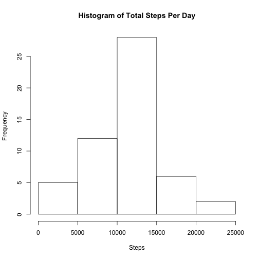

```r
stepsperday<-as.vector(tapply(act$step,act$date,sum))
hist(stepsperday,main="Histogram of Total Steps Per Day",xlab="Steps")
```

The mean is

```r
mean(stepsperday,na.rm=TRUE)
```

```
## [1] 10766
```

The median is

```r
median(stepsperday,na.rm=TRUE)
```

```
## [1] 10765
```

## What is the average daily activity pattern?

Average the number of steps for each interval for all days removing the missing. Plot that versus intervals in a day

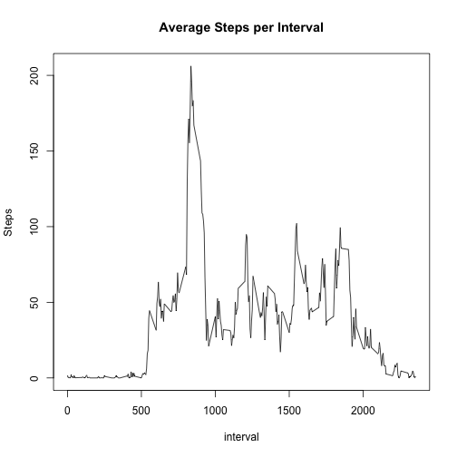

```r
averagesteps<-tapply(act$steps,act$interval,mean,na.rm=TRUE)
plot(names(averagesteps),as.vector(averagesteps),type="l",main="Average Steps per Interval",ylab="Steps",xlab="interval")
```

## Imputing missing values

Determine the step intervals that are missing data

```r
sum(is.na(act$steps))
```

```
## [1] 2304
```

Replace the missing value with the mean of the average number of steps for that interval

```r
temp<-cbind(as.array(act$steps),averagesteps)
problems<-which(is.na(temp))
temp[problems,1]<-temp[problems,2]
act2<-act
act2$steps<-temp[,1]
```

repeat the analysis steps per day after the imputation

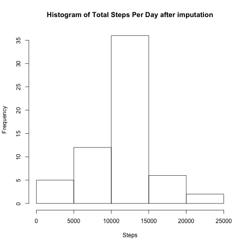

```r
stepsperday2<-as.vector(tapply(act2$step,act2$date,sum))
hist(stepsperday2,main="Histogram of Total Steps Per Day after imputation",xlab="Steps")
```

The mean is

```r
mean(stepsperday2)
```

```
## [1] 10766
```

The median is

```r
median(stepsperday2)
```

```
## [1] 10766
```

There was no impact of this imputation method on the mean, and it only slightly increased the median from 10765 to 10766

## Are there differences in activity patterns between weekdays and weekends?

We will use the imputed data set for this analysis.

```r
act2$date<-as.Date(as.character(act2$date,"%Y-%m-%d"))
week<-vector()
week[!weekdays(act2$date) %in% c("Saturday","Sunday")]="Weekday"
week[weekdays(act2$date) %in% c("Saturday","Sunday")]="Weekend"
act2$week<-week
act2$week<-as.factor(as.character(act2$week))
```

plots the average step during the week and on the weekend over the course of a day

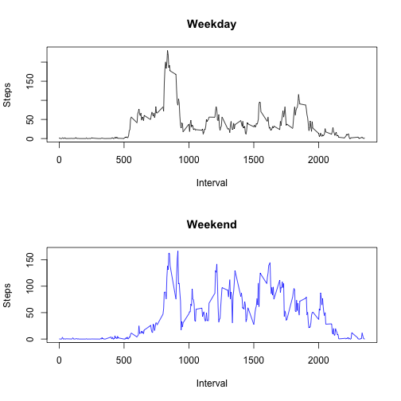

```r
weekday<-act2[act2$week=="Weekday",]
weekend<-act2[act2$week=="Weekend",]
aveweekday<-tapply(weekday$steps,weekday$interval,mean)
aveweekend<-tapply(weekend$steps,weekend$interval,mean)
par(cex=1.2, mfrow=c(2,1))
plot(names(aveweekday),as.vector(aveweekday),type="l",main="Weekday",ylab="Steps",xlab="Interval")
plot(names(aveweekend),as.vector(aveweekend),type="l",main="Weekend",ylab="Steps",xlab="Interval",col="blue")
```

from the graphs it appears the steps start up later in the day on weekend, but there are also more total steps on average on the weekend which we can show by look at the total average steps.  
mean for an average weekday

```r
sum(aveweekday)
```

```
## [1] 10256
```

mean for an average weekend

```r
sum(aveweekend)
```

```
## [1] 12202
```

So the subject took on average 20% more steps on a weekend day than a weekday